# week-5-qqq

## **Q1** What specific factors go into determining a brand's sustainability? *(Megan)*

### Qualitative:

#### Problem -

- After getting ratings of over 1300 brands, how can I look through each of the descriptions to identify the **most important** factors, such as standards and third-party certifications? This will guide us in our research (especially for evaluating materials) for the rest of our project.

#### Hypothesis & Claim -

- I should be able to extract the most common words (using word clouds) and most common entities (using spaCy's NER tool) to easily visualize the data. I hypothesize that getting entities will be more effective than just getting common words.

#### Context, Motivation & Rationale -

- I want to identify popular environmental clothing standards and certifications in order to evaluate the sustainability of different clothing materials.

#### Assumptions & Biases -

- Assume spaCy's NER tool properly extracts entities (otherwise certifications/standards could go unnoticed)

#### Definitions, Data, and Methods -

- Data: descriptions from the brand datasets we made (brand_info.csv, gou_recommended.csv, sustainable_review_ratings.csv)
- Methods:
  - **Word clouds**: Combine all descriptions into a singular string, then use Python's Counter() method to get the most common words. Create words clouds for each dataset, then for the overall brands.
  - **Most common entities**: For each description in all three datasets, extract all entities and use Python's Counter() method to get the most common ones. Manually look through the entities to get standards/certificates.

```python
import pandas as pd
import spacy
from wordcloud import WordCloud
import matplotlib.pyplot as plt
from collections import Counter
```

```python
# import datasets
brand_df = pd.read_csv('../data/brand_info.csv')
brand_df.head()
```

|  | brand | overall_rating | planet_score | people_score | animals_score | description |
| --- | --- | --- | --- | --- | --- | --- |
| 0 | Princess Polly | 2 | 2.0 | 2.0 | 4.0 | Our “Planet” rating evaluates brands based on ... |
| 1 | Brandy Melville | 1 | 1.0 | 1.0 | 0.0 | This brand provides insufficient relevant info... |
| 2 | Shein | 1 | 1.0 | 1.0 | 2.0 | Our “Planet” rating evaluates brands based on ... |
| 3 | Nike | 3 | 3.0 | 3.0 | 2.0 | Our “Planet” rating evaluates brands based on ... |
| 4 | Abercrombie & Fitch | 2 | 2.0 | 2.0 | 2.0 | Abercrombie & Fitch is owned by Abercrombie Ab... |

```python
gou_recommended_df = pd.read_csv('../data/gou_recommended.csv')
gou_recommended_df.head()
```

|  | brand | overall_rating | planet_score | people_score | animals_score | description |
| --- | --- | --- | --- | --- | --- | --- |
| 0 | Enfant Terrible | 4 | 5 | 4 | 4.0 | Enfant Terrible's environment rating is 'great... |
| 1 | milo+nicki | 4 | 5 | 3 | 4.0 | milo+nicki's environment rating is 'great'. It... |
| 2 | Birdsong | 4 | 5 | 5 | 3.0 | Birdsong's environment rating is 'great'. It u... |
| 3 | DAYWEARLAB | 4 | 5 | 3 | 3.0 | DAYWEARLAB's environment rating is 'great'. It... |
| 4 | LOVETRUST | 4 | 4 | 3 | 5.0 | LOVETRUST's environment rating is 'good'. It u... |

```python
sustainable_review_df = pd.read_csv('../data/sustainable_review_ratings.csv', usecols=['Brand', 'Rating', 'Description'])
sustainable_review_df.head()
```

|  | Brand | Rating | Description |
| --- | --- | --- | --- |
| 0 | A-dam | 4 | A-dam is a sustainable fashion brand that is m... |
| 1 | A Natural Connection | 4 | In a world where sustainability is becoming mo... |
| 2 | AFROBLONDE | 4 | Our “Planet” rating evaluates brands based on ... |
| 3 | Adidas by Stella McCartney | 4 | Adidas by Stella McCartney is a renowned brand... |
| 4 | A.BCH | 5 | \nA.BCH, a leading sustainable fashion brand, ... |

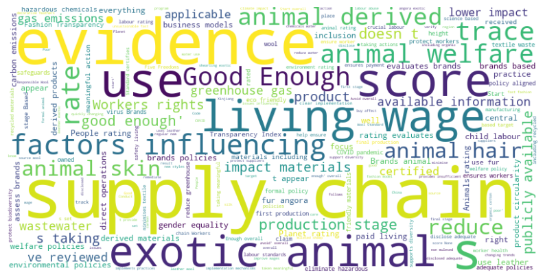

```python
# Word cloud for popular brands

text = ''

for description in brand_df['description']:
    if description:
        text += str(description)

# Generate word cloud
wordcloud = WordCloud(width = 800, height = 400, background_color ='white').generate(text)

# Display word cloud using matplotlib
plt.figure(figsize = (10, 8))
plt.imshow(wordcloud, interpolation='bilinear')
plt.axis("off")
plt.show()
```

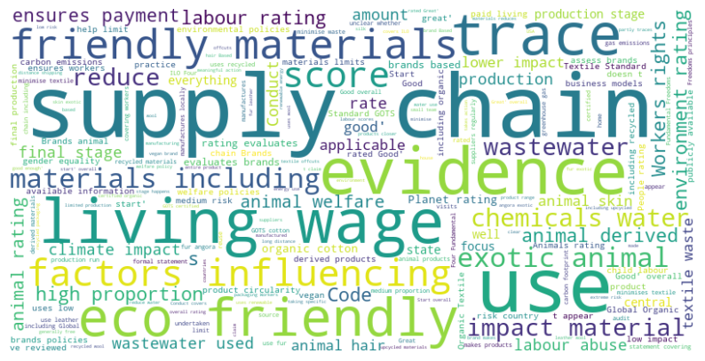

```python
# Word cloud for Good On You's recommended brands

text = ''

for description in gou_recommended_df['description']:
    if description:
        text += str(description)

# Generate word cloud
wordcloud = WordCloud(width = 800, height = 400, background_color ='white').generate(text)

# Display word cloud using matplotlib
plt.figure(figsize = (10, 8))
plt.imshow(wordcloud, interpolation='bilinear')
plt.axis("off")
plt.show()
```

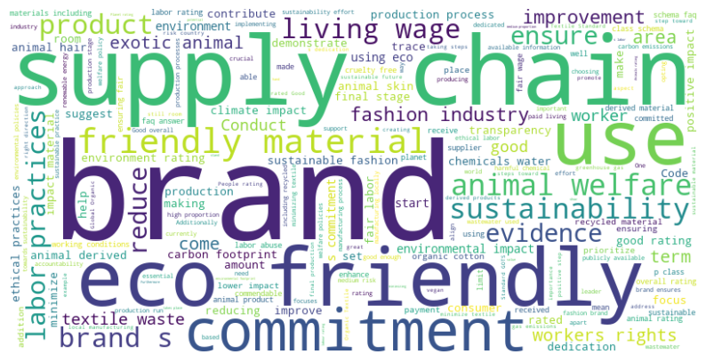

```python
# Word cloud for Sustainable Review's brands

text = ''

for description in sustainable_review_df['Description']:
    if description:
        text += str(description)

# Generate word cloud
wordcloud = WordCloud(width = 800, height = 400, background_color ='white').generate(text)

# Display word cloud using matplotlib
plt.figure(figsize = (10, 8))
plt.imshow(wordcloud, interpolation='bilinear')
plt.axis("off")
plt.show()
```

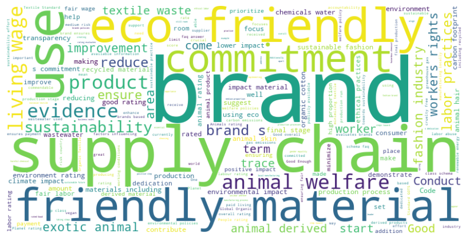

```python
# Word cloud for all three datasets

text = ''

for description in brand_df['description']:
    if description:
        text += str(description)

for description in gou_recommended_df['description']:
    if description:
        text += str(description)

for description in sustainable_review_df['Description']:
    if description:
        text += str(description)

# Generate word cloud
wordcloud = WordCloud(width = 800, height = 400, background_color ='white').generate(text)

# Display word cloud using matplotlib
plt.figure(figsize = (10, 8))
plt.imshow(wordcloud, interpolation='bilinear')
plt.axis("off")
plt.show()
```

```python
# !python -m spacy download en_core_web_lg

nlp_web = spacy.load("en_core_web_lg")
```

```python
# Popular brands (list created by us)

ner_results = []
entities = []

for description in brand_df['description']:
    text = str(description)
    doc_web = nlp_web(text)
    ner_results.append(doc_web.ents)

brand_df['ner_results'] = ner_results

for ner_result in brand_df['ner_results']:
    for ent in ner_result:
        entities.append(ent.text)
        print(ent.text, ent.label_)
```

```
angora ORG
Brandy Melville PERSON
SHEIN ORG
SHEIN ORG
0-10% PERCENT
2022 DATE
SHEIN ORG
angora ORG
first ORDINAL
SHEIN ORG
Nike ORG
2025 DATE
Nike ORG
Fair Labor Association ORG
51-60% PERCENT
2022 DATE
Nike ORG
angora ORG
first ORDINAL
Nike ORG
Abercrombie & Fitch ORG
Abercrombie Abercrombie & Fitch Co. ORG
Abercrombie & Fitch ORG
Abercrombie & Fitch ORG
31-40% PERCENT
2023 DATE
Xinjiang GPE
China GPE
Uyghur NORP
Abercrombie & Fitch ORG
angora ORG
first ORDINAL
Abercrombie & Fitch ORG
Amazon ORG
Amazon ORG
Amazon ORG
21-30% PERCENT
2021 DATE
Xinjiang GPE
China GPE
```

[output cut: 643 more lines]

```
Uyghur NORP
Victoria PERSON
YesStyle ORG
nan PERSON
nan PERSON
nan PERSON
nan PERSON
Esprit ORG
Business Social Compliance Initiative Code of Conduct - BSCI ORG
51-60% PERCENT
2022 DATE
Five CARDINAL
angora ORG
first ORDINAL
Esprit ORG
```

```python
# Good On You's recommended brands

ner_results = []

for description in gou_recommended_df['description']:
    text = str(description)
    doc_web = nlp_web(text)
    ner_results.append(doc_web.ents)

gou_recommended_df['ner_results'] = ner_results

for ner_result in gou_recommended_df['ner_results']:
    for ent in ner_result:
        entities.append(ent.text)
```

```python
# Sustainable Review's brand ratings

ner_results = []

for description in sustainable_review_df['Description']:
    text = str(description)
    doc_web = nlp_web(text)
    ner_results.append(doc_web.ents)

sustainable_review_df['ner_results'] = ner_results

for ner_result in sustainable_review_df['ner_results']:
    for ent in ner_result:
        entities.append(ent.text)
```

```python
ent_counts = Counter(entities)

ent_counts
```

```
Counter({'One': 1692,
         'angora': 1206,
         'a Code of Conduct': 1010,
         'GOTS': 780,
         'Global Organic Textile Standard': 491,
         'Code of Conduct': 486,
         'USA': 226,
         'Four': 213,
         'one': 210,
         'Portugal': 179,
         'first': 172,
         'second': 143,
         'Italy': 134,
         'the International Labour Organization': 128,
         'Not Good Enough': 120,
         'class="schema-faq-answer">Yes': 120,
         'A Code of Conduct': 114,
         'class="schema-faq-': 114,
         'the European Union': 108,
         'Australia': 101,
         'today': 96,
         'UK': 86,
         'the Global Organic Textile Standard': 82,
         'Bluesign': 79,
         'the Fair Wear Foundation': 74,
         'Adidas': 65,
         'the Responsible Wool Standard': 64,
         'Nike': 60,
         'Paris': 60,
         '2022': 59,
         '“Not Good Enough': 58,
         'WeAreNativ': 58,
         'Canada': 57,
         'Fairtrade International': 54,
         'Houdini': 54,
         'Social Accountability International': 53,
         'Kimai': 52,
         'Purnama': 52,
         'PANGAIA': 50,
         'Tomorrow': 50,
```

[output cut: 946 more lines]

```
         'Sylven New York': 12,
         'Studio Courtenay': 12,
         'Tetiana K': 12,
         'Campamento': 12,
         'The Recycled Planet': 12,
         'True Tribe': 12,
         'Tomorrow Denim': 12,
         'Wilson': 12,
         'Frenchy': 12,
         'Wemoto': 12,
         'Will’s Vegan Store': 12,
         'WACCOWACCO': 12,
         'YU STEPANEL': 12,
         'Leather Working Group': 11,
         ...})
```

Relevant entities:

- Global Organic Textile Standard (1353 times)
- International Labour Organization (158)
- Bluesign (79)
- Responsible Wool Standard (64)
- Fairtrade International (54)
- Social Accountability International (53)
- PETA (46)
- Responsible Down Standard (39)
- Business Social Compliance Initiative Code of Conduct (49)
- Fair Trade USA (20)

### Qualitative (pt. 2):

#### Answer/Update to Question/Claim

I was able to parse through each of the brand's descriptions to create word clouds and extract entities. We now have a better idea of the popular standards, certificates, and organization to look for when evaluating materials/brands.

#### Summary

- Global Organic Textile Standard (1353 times)
- International Labour Organization (158)
- Bluesign (79)
- Responsible Wool Standard (64)
- Fairtrade International (54)
- Social Accountability International (53)
- PETA (46)
- Responsible Down Standard (39)
- Business Social Compliance Initiative Code of Conduct (49)
- Fair Trade USA (20)

We will use these to help us find an effective calculator for textile sustainability. We will examine the criteria and see if they take the above standards into consideration.

#### Uncertainty, Limitations & Caveats

- I did not combine the three datasets, so brands could have been repeated (meaning words/entities were could have also been repeated).
- I manually found the relevant entities, so I might have omitted some important standards, certificates, or organizations (either from not knowing about them, human error, etc.).

#### Next Steps

Next, we will combine the datasets to remove duplicates and create an average overall brand rating. This allows us to quickly reference a brand and also makes it easier to analyze scores and descriptions.

## **Q2** How can comprehensive brand ratings be collected from Sustainable Review? *(Sabrina)*

### Qualitative:

#### Problem -

- Prior web scraping methods for collecting brand ratings from Sustainable Review took ~30 minutes
- Despite attempting up to 3 times, the code always failed to access a few links
- Only collecting the headers in brand descriptions did not provide enough information about how the brand rating was determined
- How can the web scraping process be broken down to speed up the collection process and ensure all links are accessed?

#### Hypothesis & Claim -

- We can break down the web scraping process by writing out a function which specifically scrapes brand review pages by Sustainable Review
- Increasing the number of attempts will increase the chances that all links are accessed.

#### Context, Motivation & Rationale -

- We are motivated to shorten the length of time it takes to scrape the website is important because the code must be run every time the website updates.
- Ensuring that the resulting dataset is comprehensive will allow us to compare the ratings of more brands across organizations
- Webscraping with the Python library BeautifulSoup because it is popular and well documented
- Sustainable Review documents all of the research which ultimately determines the overall sustainability score in their brand description

#### Definitions, Data, and Methods -

- Sustainable Review publishes sustinability content weekly
- Data will be collected from the Sustainability Review website
- The Python library requests which allows us to define the number of attempts
- Webscraping with the Python library BeautifulSoup to visit the webpage for each brand review and get the overall rating and brand description

#### Biases & Assumptions -

- All brand review pages include the brand name, rating, and description
- All brand review pages are structured the same
- Breaking down the web scraping process will speed it up

### Quantitative:

```python
# imports
import requests
from requests.adapters import HTTPAdapter
from urllib3.util.retry import Retry
from bs4 import BeautifulSoup
import pandas as pd
import re
import csv
```

```python
# create session
session = requests.Session()
# retry five times in case of exception
retry = Retry(connect=5, backoff_factor=0.5)
# apply delays between attempts
adapter = HTTPAdapter(max_retries=retry)
session.mount('https://', adapter)
```

```python
# get page range
first_page_url = "https://sustainablereview.com/brand-ratings/"
first_page = session.get(first_page_url)
content = BeautifulSoup(first_page.text, 'html.parser')
# last page number out of all page numbers
last_page_num = str(content.find_all('a', class_="page-numbers")[-1]).split('>')[1].split('<')[0]

print(last_page_num)
```

```
39
```

```python
# get brand links from all pages
brand_urls = []
# loop through all pages
for i in range(1, int(last_page_num) + 1):
    # scrape first page
    if i == 1:
        page = first_page
    # scrape remaining pages
    else:
        next_page_url = "https://sustainablereview.com/brand-ratings/?query-48-page="
        page = session.get(next_page_url + str(i))

    # content
    content = BeautifulSoup(page.text, 'html.parser')

    # links to brand reviews
    page_links = content.find_all("a")
    brands = set(link.get('href') for link in page_links if ("https://sustainablereview.com/brand-ratings/" in link.get('href')) and (link.get('href') != "https://sustainablereview.com/brand-ratings/"))

    # update brand urls list
    brand_urls.extend(brands)

print(brand_urls)
```

```
['https://sustainablereview.com/brand-ratings/aarven/', 'https://sustainablereview.com/brand-ratings/a-a-k-s/', 'https://sustainablereview.com/brand-ratings/aestethic-london/', 'https://sustainablereview.com/brand-ratings/a-dam/', 'https://sustainablereview.com/brand-ratings/adele-dejak/', 'https://…
```

```python
# create dataframe
sustainable_review_df = pd.DataFrame(columns=['Brand', 'Rating', 'Description', 'URL'])
```

```python
# define function to scrape for brand data
def scrape_sustainable_review(urls, df):
    for url in urls:
        try:
            # search for brand review
            review = session.get(url)

            # content
            content = BeautifulSoup(review.text, 'html.parser')

            # brand
            brand = content.find('h1', class_='post-title').get_text()

            # rating
            information = content.find('div', class_='InfoBox')
            rating = information.find('p').get_text().split(" ")[3]

            # description
            body = content.find('div', class_='col-md-12 col-lg-9')
            # find similar brands section of description
            similar_brands = body.find_all('div', class_='col-sm-6 col-md-4')
            # clear similar brands section
            for rec in similar_brands:
                for child in rec.findChildren():
                    child.extract()
            # clean description
            description = str(body.find_all('p')).replace('<p>', '').replace('</p>,', '').replace('</p>', '').replace("[","").replace("]","")

            # update dataframe
            df.loc[len(df.index)] = [brand, rating, description, url]

        except Exception as e:
            print(str(brand) + ": " + str(e))
```

```python
# scrape for sustainable review data
scrape_sustainable_review(brand_urls, sustainable_review_df)
```

```
Test Page: 'NoneType' object has no attribute 'find'
```

```python
# visualize first 10 rows of the new dataset
sustainable_review_df.head(10)
```

|  | Brand | Rating | Description | URL |
| --- | --- | --- | --- | --- |
| 0 | AARVEN | 4 | The AARVEN brand is a renowned apparel and jew... | https://sustainablereview.com/brand-ratings/aa... |
| 1 | A A K S | 4 | A A K S is a unique and sustainable brand that... | https://sustainablereview.com/brand-ratings/a-... |
| 2 | Aestethic London | 5 | Aestethic London is an environmentally conscio... | https://sustainablereview.com/brand-ratings/ae... |
| 3 | A-dam | 4 | A-dam is a sustainable fashion brand that is m... | https://sustainablereview.com/brand-ratings/a-... |
| 4 | Adele Dejak | 3 | Adele Dejak is a brand that is making efforts ... | https://sustainablereview.com/brand-ratings/ad... |
| 5 | Absolutely Bear | 4 | Absolutely Bear is an eco-conscious brand that... | https://sustainablereview.com/brand-ratings/ab... |
| 6 | Adarche Clothing | 4 | When it comes to sustainability, Adarche Cloth... | https://sustainablereview.com/brand-ratings/ad... |
| 7 | A.BCH | 5 | \nA.BCH, a leading sustainable fashion brand, ... | https://sustainablereview.com/brand-ratings/a-... |
| 8 | AFROBLONDE | 4 | Our “Planet” rating evaluates brands based on ... | https://sustainablereview.com/brand-ratings/af... |
| 9 | (di)vision | 4 | (di)vision is a brand that takes sustainabilit... | https://sustainablereview.com/brand-ratings/di... |

```python
len(sustainable_review_df)
```

```
1140
```

```python
# export csv file
sustainable_review_df.to_csv('../data/sustainable_review_ratings.csv')
```

### Qualitative (pt. 2):

#### Answer/Update to Question/Claim

- We successfully broke down the web scraping process by writing out a function which specifically scrapes brand review pages by Sustainable Review and takes in a list of links.
- As no active links were missed, increasing the number of attempts may have improved the chances that all links are accessed, but writing out a function made a greater difference.

#### Summary & Re-contextualization

- The average runtime for scraping the Sustainable Review website dropped from ~30 minutes to ~6 minutes, which is a major improvement.
- Collecting the full brand description rather than just the headings in the brand description yielded a lot more information about how brands were rated
- The Sustainable Review dataset is now at the same quality as the Eco-Stylist and Good on You datasets

#### Uncertainty, Limitations & Caveats

- Some links may still fail to be accessed even with more tries
- The brand description is much longer than just the headers, meaning the text includes more irrelevant words that will not help predict the brand rating

#### New Problems & Next Steps

- Since Megan worked on extracting relevant words from brand descriptions, adding the extracted keywords into this dataset and using them to calculate our own sustainability score would be the next step
- The quality of the dataset has also been improved, so it can be combined with the eco-stylist dataset for easier comparisons across ratings

#### Story & Domain Knowledge

- Scraping the brand ratings from Sustainable Review again allowed us to improve upon prior code, making it more efficient, less redundant, and more reliable
- We relied on domain knowledge about Python to determine that scraping the entire brand description would be most helpful for calculating a sustainability score

## **Q3** How can we compare ratings from organizatins like Good on You, Eco-Stylist, and Sustainable Review?

### Qualitative:

#### Problem -

- To compare brand ratings across organizations, we must read in 4 separate datasets and repeatedly combine them
- Each organization rated their brands on different scales and criteria, meaning some brands are ranked by category rather than a rating out of 5
- How can we combine all four datasets in an understandable way and compare different types of brand ratings?

#### Hypothesis & Claim -

- We will join all four datasets on the name of the brand and standardize the overall brand rating from each organization to calculate the average rating for a brand
- Converting qualitative rankings to quantiative ratings will make brand ratings easier to compare because quantiative ratings are easier to scale

#### Context, Motivation & Rationale -

- We are motivated to combine the datasets in a clear and understandable way so that we only have to read in 1 dataset in the future when conducting data analysis and calculating sustainability scores
- Combining the datasets beforehand also removes the possibility that they will be combined incorrectly later
- Synthesizing the overall brand ratings through an average makes sense since they all have well documented methodologies for determining brand ratings
- Data manipulation in the Python library Pandas because it is popular and well documented

#### Definitions, Data, and Methods -

- Sustainability Review publishes sustainability content weekly
- Eco-Stylist is a guide to ethical and eco-friendly fashion
- Good on You is home to thousands of brand ratings, articles, and sustainable fashion expertise
- Data will be read in from the existing data folder in our GitHub repository
- Datasets will be joined and categorical ratings will be converted using the industry standard Python library Pandas for data analysis and manipulation

#### Biases & Assumptions -

- All brand rankings hold the same weight (given that they are being averaged)
- All brand names are unique and can be used as the key to join on

### Quantitative:

```python
# read in datasets
eco_stylist = pd.read_csv("../data/eco_stylist_ratings.csv")
sustainable_review = pd.read_csv("../data/sustainable_review_ratings.csv")
good_on_you_recommended = pd.read_csv("../data/gou_recommended.csv")
good_on_you = pd.read_csv("../data/brand_info.csv")

eco_stylist.head(5)
```

|  | Unnamed: 0 | Brand | Overall | Transparency | Fair Labor | Sustainably Made | URL |
| --- | --- | --- | --- | --- | --- | --- | --- |
| 0 | 0 | KNOWN SUPPLY | Certified | Good | Excellent | Good | https://www.eco-stylist.com/ethical-brand/know... |
| 1 | 1 | AMENDI | Certified | Excellent | Fair | Good | https://www.eco-stylist.com/ethical-brand/amendi/ |
| 2 | 2 | SANVT | Certified | Excellent | Good | Good | https://www.eco-stylist.com/ethical-brand/sanvt/ |
| 3 | 3 | Patagonia | Gold | Excellent | Excellent | Excellent | https://www.eco-stylist.com/ethical-brand/pata... |
| 4 | 4 | Scotch & Soda | Silver | Excellent | Fair | Excellent | https://www.eco-stylist.com/ethical-brand/scot... |

```python
# correct index column for sustainable_review and eco_stylist
eco_stylist.drop(columns='Unnamed: 0', inplace=True)
sustainable_review.drop(columns='Unnamed: 0', inplace=True)

eco_stylist.head(5)
```

|  | Brand | Overall | Transparency | Fair Labor | Sustainably Made | URL |
| --- | --- | --- | --- | --- | --- | --- |
| 0 | KNOWN SUPPLY | Certified | Good | Excellent | Good | https://www.eco-stylist.com/ethical-brand/know... |
| 1 | AMENDI | Certified | Excellent | Fair | Good | https://www.eco-stylist.com/ethical-brand/amendi/ |
| 2 | SANVT | Certified | Excellent | Good | Good | https://www.eco-stylist.com/ethical-brand/sanvt/ |
| 3 | Patagonia | Gold | Excellent | Excellent | Excellent | https://www.eco-stylist.com/ethical-brand/pata... |
| 4 | Scotch & Soda | Silver | Excellent | Fair | Excellent | https://www.eco-stylist.com/ethical-brand/scot... |

```python
# check column types for eco-stylist prior to encoding
eco_stylist.dtypes
```

```
Brand               object
Overall             object
Transparency        object
Fair Labor          object
Sustainably Made    object
URL                 object
dtype: object
```

```python
# order categorical rankings in rating columns
eco_stylist['Overall'] = pd.Categorical(eco_stylist['Overall'], categories=['Certified', 'Silver', 'Gold'], ordered=True)
subratings = ['Transparency', 'Fair Labor', 'Sustainably Made']
for subrating in subratings:
    eco_stylist[subrating] = pd.Categorical(eco_stylist[subrating], categories=['Good', 'Fair', 'Excellent'], ordered=True)

eco_stylist.dtypes
```

```
Brand                 object
Overall             category
Transparency        category
Fair Labor          category
Sustainably Made    category
URL                   object
dtype: object
```

```python
# encode categorical rankings from eco_stylist into quantiative ratings
eco_stylist_encoded = eco_stylist.copy()
categorical_columns = eco_stylist_encoded.select_dtypes(['category']).columns
eco_stylist_encoded[categorical_columns] = eco_stylist_encoded[categorical_columns].apply(lambda x: x.cat.codes + 1)

eco_stylist_encoded.head(5)
```

|  | Brand | Overall | Transparency | Fair Labor | Sustainably Made | URL |
| --- | --- | --- | --- | --- | --- | --- |
| 0 | KNOWN SUPPLY | 1 | 1 | 3 | 1 | https://www.eco-stylist.com/ethical-brand/know... |
| 1 | AMENDI | 1 | 3 | 2 | 1 | https://www.eco-stylist.com/ethical-brand/amendi/ |
| 2 | SANVT | 1 | 3 | 1 | 1 | https://www.eco-stylist.com/ethical-brand/sanvt/ |
| 3 | Patagonia | 3 | 3 | 3 | 3 | https://www.eco-stylist.com/ethical-brand/pata... |
| 4 | Scotch & Soda | 2 | 3 | 2 | 3 | https://www.eco-stylist.com/ethical-brand/scot... |

```python
# scale quantiative ratings up from 1-3 to 1-5
eco_stylist_scaled = eco_stylist_encoded.copy()
rating_columns = eco_stylist_scaled.select_dtypes(['int8']).columns
eco_stylist_scaled[rating_columns] = eco_stylist_scaled[rating_columns].apply(lambda x: round(((5/3) * x), 1))

eco_stylist_scaled.head(5)
```

|  | Brand | Overall | Transparency | Fair Labor | Sustainably Made | URL |
| --- | --- | --- | --- | --- | --- | --- |
| 0 | KNOWN SUPPLY | 1.7 | 1.7 | 5.0 | 1.7 | https://www.eco-stylist.com/ethical-brand/know... |
| 1 | AMENDI | 1.7 | 5.0 | 3.3 | 1.7 | https://www.eco-stylist.com/ethical-brand/amendi/ |
| 2 | SANVT | 1.7 | 5.0 | 1.7 | 1.7 | https://www.eco-stylist.com/ethical-brand/sanvt/ |
| 3 | Patagonia | 5.0 | 5.0 | 5.0 | 5.0 | https://www.eco-stylist.com/ethical-brand/pata... |
| 4 | Scotch & Soda | 3.3 | 5.0 | 3.3 | 5.0 | https://www.eco-stylist.com/ethical-brand/scot... |

```python
# normalize brand names function
def normalize_brand_names(df, brand_col):
    try:
        norm_brands = []
        for brand in df[brand_col]:
            # drop all non-special characters
            norm_brands.append(''.join(e.lower() for e in brand if e.isalnum()))

        # create new column for normalized brand names
        df['norm_brands'] = norm_brands

    except Exception as e:
        print(e)
```

```python
# normalize eco-stylist brand names
normalize_brand_names(eco_stylist_scaled, 'Brand')

# check that all brand names remain unique
print("# of brand names: " + str(len(eco_stylist_scaled['Brand'].unique())))
print("# of normalized brand names: " + str(len(eco_stylist_scaled['norm_brands'].unique())))

eco_stylist_scaled.head(5)
```

```
# of brand names: 102
# of normalized brand names: 102
```

|  | Brand | Overall | Transparency | Fair Labor | Sustainably Made | URL | norm_brands |
| --- | --- | --- | --- | --- | --- | --- | --- |
| 0 | KNOWN SUPPLY | 1.7 | 1.7 | 5.0 | 1.7 | https://www.eco-stylist.com/ethical-brand/know... | knownsupply |
| 1 | AMENDI | 1.7 | 5.0 | 3.3 | 1.7 | https://www.eco-stylist.com/ethical-brand/amendi/ | amendi |
| 2 | SANVT | 1.7 | 5.0 | 1.7 | 1.7 | https://www.eco-stylist.com/ethical-brand/sanvt/ | sanvt |
| 3 | Patagonia | 5.0 | 5.0 | 5.0 | 5.0 | https://www.eco-stylist.com/ethical-brand/pata... | patagonia |
| 4 | Scotch & Soda | 3.3 | 5.0 | 3.3 | 5.0 | https://www.eco-stylist.com/ethical-brand/scot... | scotchsoda |

```python
# normalize sustainable review brand names and check that all brand names remain unique
normalize_brand_names(sustainable_review, 'Brand')

# check that all brand names remain unique
print("# of brand names: " + str(len(sustainable_review['Brand'].unique())))
print("# of normalized brand names: " + str(len(sustainable_review['norm_brands'].unique())))

sustainable_review.head(5)
```

```
# of brand names: 1140
# of normalized brand names: 1140
```

|  | Brand | Rating | Description | URL | norm_brands |
| --- | --- | --- | --- | --- | --- |
| 0 | AARVEN | 4 | The AARVEN brand is a renowned apparel and jew... | https://sustainablereview.com/brand-ratings/aa... | aarven |
| 1 | A A K S | 4 | A A K S is a unique and sustainable brand that... | https://sustainablereview.com/brand-ratings/a-... | aaks |
| 2 | Aestethic London | 5 | Aestethic London is an environmentally conscio... | https://sustainablereview.com/brand-ratings/ae... | aestethiclondon |
| 3 | A-dam | 4 | A-dam is a sustainable fashion brand that is m... | https://sustainablereview.com/brand-ratings/a-... | adam |
| 4 | Adele Dejak | 3 | Adele Dejak is a brand that is making efforts ... | https://sustainablereview.com/brand-ratings/ad... | adeledejak |

```python
# normalize good on you brand names and check that all brand names remain unique
normalize_brand_names(good_on_you, 'brand')

# check that all brand names remain unique
print("# of brand names: " + str(len(good_on_you['brand'].unique())))
print("# of normalized brand names: " + str(len(good_on_you['norm_brands'].unique())))

good_on_you.head(5)
```

```
# of brand names: 105
# of normalized brand names: 105
```

|  | brand | overall_rating | planet_score | people_score | animals_score | description | norm_brands |
| --- | --- | --- | --- | --- | --- | --- | --- |
| 0 | Princess Polly | 2 | 2.0 | 2.0 | 4.0 | Our “Planet” rating evaluates brands based on ... | princesspolly |
| 1 | Brandy Melville | 1 | 1.0 | 1.0 | 0.0 | This brand provides insufficient relevant info... | brandymelville |
| 2 | Shein | 1 | 1.0 | 1.0 | 2.0 | Our “Planet” rating evaluates brands based on ... | shein |
| 3 | Nike | 3 | 3.0 | 3.0 | 2.0 | Our “Planet” rating evaluates brands based on ... | nike |
| 4 | Abercrombie & Fitch | 2 | 2.0 | 2.0 | 2.0 | Abercrombie & Fitch is owned by Abercrombie Ab... | abercrombiefitch |

```python
# normalize recommendedgood on you brand names and check that all brand names remain unique
normalize_brand_names(good_on_you_recommended, 'brand')

# check that all brand names remain unique
print("# of brand names: " + str(len(good_on_you_recommended['brand'].unique())))
print("# of normalized brand names: " + str(len(good_on_you_recommended['norm_brands'].unique())))

good_on_you_recommended.head(5)
```

```
# of brand names: 454
# of normalized brand names: 453
```

|  | brand | overall_rating | planet_score | people_score | animals_score | description | norm_brands |
| --- | --- | --- | --- | --- | --- | --- | --- |
| 0 | Enfant Terrible | 4 | 5 | 4 | 4.0 | Enfant Terrible's environment rating is 'great... | enfantterrible |
| 1 | milo+nicki | 4 | 5 | 3 | 4.0 | milo+nicki's environment rating is 'great'. It... | milonicki |
| 2 | Birdsong | 4 | 5 | 5 | 3.0 | Birdsong's environment rating is 'great'. It u... | birdsong |
| 3 | DAYWEARLAB | 4 | 5 | 3 | 3.0 | DAYWEARLAB's environment rating is 'great'. It... | daywearlab |
| 4 | LOVETRUST | 4 | 4 | 3 | 5.0 | LOVETRUST's environment rating is 'good'. It u... | lovetrust |

```python
# identify duplicate normalized brand name
norm_brands = []
for brand in good_on_you_recommended['norm_brands']:
    if brand not in norm_brands:
        # add brand to list if it is not a duplicate
        norm_brands.append(brand)
    else:
        print("Duplicate brand name: " + brand)
```

```
Duplicate brand name: mori
```

```python
# extract columns with duplicate normalized brand name
good_on_you_recommended[good_on_you_recommended['norm_brands'] == 'mori']
```

|  | brand | overall_rating | planet_score | people_score | animals_score | description | norm_brands |
| --- | --- | --- | --- | --- | --- | --- | --- |
| 73 | MORI | 3 | 3 | 2 | 4.0 | MORI's environment rating is 'it's a start'. I... | mori |
| 124 | mori | 4 | 5 | 4 | 4.0 | Our “Planet” rating evaluates brands based on ... | mori |

```python
# clean and rename columns of all datasets
eco_stylist_scaled.drop(columns='URL', inplace=True)
eco_stylist_scaled.rename(columns={'Brand': 'es_brand', 'Overall':'es_rating', 'Transparency':'es_transparency', 'Fair Labor':'es_fair_labor', 'Sustainably Made':'es_sustainably_made'}, inplace=True)

sustainable_review.drop(columns='URL', inplace=True)
sustainable_review.rename(columns={'Brand': 'sr_brand', 'Rating':'sr_rating', 'Description':'sr_description'}, inplace=True)

good_on_you.rename(columns={'brand': 'goy_brand', 'overall_rating':'goy_rating', 'planet_score':'goy_planet', 'people_score':'goy_people', 'animals_score':'goy_animals', 'description':'goy_description'}, inplace=True)

good_on_you_recommended.rename(columns={'brand': 'goyr_brand', 'overall_rating':'goyr_rating', 'planet_score':'goyr_planet', 'people_score':'goyr_people', 'animals_score':'goyr_animals', 'description':'goyr_description'}, inplace=True)
```

```python
# check for duplicate normalized brand name in other datasets
for df in [eco_stylist_scaled, sustainable_review, good_on_you]:
    for brand in df['norm_brands']:
        if 'mori' == brand:
            duplicate = df[df['norm_brands'] == 'mori']

            print(duplicate)
            print(duplicate.index)
```

```
    sr_brand  sr_rating                                     sr_description  \
652     mori          4  Our “Planet” rating evaluates brands based on ...

    norm_brands
652        mori
Index([652], dtype='int64')
```

```python
# manually alter duplicate normalized brand name to join datasets
good_on_you_recommended['norm_brands'].loc[good_on_you_recommended['goyr_brand'] == 'MORI'] = 'mori2'
good_on_you_recommended[good_on_you_recommended['goyr_brand'] == 'MORI']
```

|  | goyr_brand | goyr_rating | goyr_planet | goyr_people | goyr_animals | goyr_description | norm_brands |
| --- | --- | --- | --- | --- | --- | --- | --- |
| 73 | MORI | 3 | 3 | 2 | 4.0 | MORI's environment rating is 'it's a start'. I... | mori2 |

```python
# join datasets on normalized brand names
two_brands = pd.merge(eco_stylist_scaled, sustainable_review, how='outer', on='norm_brands')
three_brands = pd.merge(two_brands, good_on_you, how='outer', on='norm_brands')
all_brand_ratings = pd.merge(three_brands, good_on_you_recommended, how='outer', on='norm_brands')

all_brand_ratings.head(5)
```

|  | es_brand | es_rating | es_transparency | es_fair_labor | es_sustainably_made | norm_brands | sr_brand | sr_rating | sr_description | goy_brand | ... | goy_planet | goy_people | goy_animals | goy_description | goyr_brand | goyr_rating | goyr_planet | goyr_people | goyr_animals | goyr_description |
| --- | --- | --- | --- | --- | --- | --- | --- | --- | --- | --- | --- | --- | --- | --- | --- | --- | --- | --- | --- | --- | --- |
| 0 | KNOWN SUPPLY | 1.7 | 1.7 | 5.0 | 1.7 | knownsupply | Known Supply | 4.0 | <a data-wpel-link="external" href="https://kno... | NaN | ... | NaN | NaN | NaN | NaN | NaN | NaN | NaN | NaN | NaN | NaN |
| 1 | AMENDI | 1.7 | 5.0 | 3.3 | 1.7 | amendi | AMENDI | 4.0 | AMENDI is a brand that is making commendable e... | NaN | ... | NaN | NaN | NaN | NaN | AMENDI | 4.0 | 4.0 | 3.0 | 4.0 | AMENDI's environment rating is 'good'. It uses... |
| 2 | SANVT | 1.7 | 5.0 | 1.7 | 1.7 | sanvt | NaN | NaN | NaN | NaN | ... | NaN | NaN | NaN | NaN | NaN | NaN | NaN | NaN | NaN | NaN |
| 3 | Patagonia | 5.0 | 5.0 | 5.0 | 5.0 | patagonia | Patagonia | 4.0 | Patagonia is a brand that focuses on sustainab... | Patagonia | ... | 4.0 | 2.0 | 4.0 | Our “Planet” rating evaluates brands based on ... | Patagonia | 4.0 | 4.0 | 2.0 | 4.0 | Our “Planet” rating evaluates brands based on ... |
| 4 | Scotch & Soda | 3.3 | 5.0 | 3.3 | 5.0 | scotchsoda | NaN | NaN | NaN | NaN | ... | NaN | NaN | NaN | NaN | NaN | NaN | NaN | NaN | NaN | NaN |

5 rows × 21 columns

```python
# compare lengths of individual datasets and joined datasets
print("Total length of individual datasets: " + str(len(eco_stylist_scaled) + len(sustainable_review) + len(good_on_you) + len(good_on_you_recommended)))
print("Total length of joined datasets: " + str(len(all_brand_ratings)))
```

```
Total length of individual datasets: 1801
Total length of joined datasets: 1327
```

```python
# combine brand name columns from each dataset
all_brand_ratings['brand'] = all_brand_ratings['es_brand']
all_brand_ratings['brand'].loc[all_brand_ratings['brand'].isnull()] = all_brand_ratings['sr_brand']
all_brand_ratings['brand'].loc[all_brand_ratings['brand'].isnull()] = all_brand_ratings['goy_brand']
all_brand_ratings['brand'].loc[all_brand_ratings['brand'].isnull()] = all_brand_ratings['goyr_brand']

print("Contains empty brand names: " + str(all_brand_ratings['brand'].isnull().values.any()))
```

```
Contains empty brand names: False
```

```python
# drop redundant brand name columns
all_brand_ratings.drop(columns=['es_brand', 'sr_brand', 'goy_brand', 'goyr_brand', 'norm_brands'], inplace=True)
all_brand_ratings.head(5)
```

|  | es_rating | es_transparency | es_fair_labor | es_sustainably_made | sr_rating | sr_description | goy_rating | goy_planet | goy_people | goy_animals | goy_description | goyr_rating | goyr_planet | goyr_people | goyr_animals | goyr_description | brand |
| --- | --- | --- | --- | --- | --- | --- | --- | --- | --- | --- | --- | --- | --- | --- | --- | --- | --- |
| 0 | 1.7 | 1.7 | 5.0 | 1.7 | 4.0 | <a data-wpel-link="external" href="https://kno... | NaN | NaN | NaN | NaN | NaN | NaN | NaN | NaN | NaN | NaN | KNOWN SUPPLY |
| 1 | 1.7 | 5.0 | 3.3 | 1.7 | 4.0 | AMENDI is a brand that is making commendable e... | NaN | NaN | NaN | NaN | NaN | 4.0 | 4.0 | 3.0 | 4.0 | AMENDI's environment rating is 'good'. It uses... | AMENDI |
| 2 | 1.7 | 5.0 | 1.7 | 1.7 | NaN | NaN | NaN | NaN | NaN | NaN | NaN | NaN | NaN | NaN | NaN | NaN | SANVT |
| 3 | 5.0 | 5.0 | 5.0 | 5.0 | 4.0 | Patagonia is a brand that focuses on sustainab... | 4.0 | 4.0 | 2.0 | 4.0 | Our “Planet” rating evaluates brands based on ... | 4.0 | 4.0 | 2.0 | 4.0 | Our “Planet” rating evaluates brands based on ... | Patagonia |
| 4 | 3.3 | 5.0 | 3.3 | 5.0 | NaN | NaN | NaN | NaN | NaN | NaN | NaN | NaN | NaN | NaN | NaN | NaN | Scotch & Soda |

```python
# reorder columns
columns = list(all_brand_ratings.columns)
columns.insert(0, columns.pop(columns.index('brand')))
all_brand_ratings = all_brand_ratings.loc[:, columns]

all_brand_ratings.head(5)
```

|  | brand | es_rating | es_transparency | es_fair_labor | es_sustainably_made | sr_rating | sr_description | goy_rating | goy_planet | goy_people | goy_animals | goy_description | goyr_rating | goyr_planet | goyr_people | goyr_animals | goyr_description |
| --- | --- | --- | --- | --- | --- | --- | --- | --- | --- | --- | --- | --- | --- | --- | --- | --- | --- |
| 0 | KNOWN SUPPLY | 1.7 | 1.7 | 5.0 | 1.7 | 4.0 | <a data-wpel-link="external" href="https://kno... | NaN | NaN | NaN | NaN | NaN | NaN | NaN | NaN | NaN | NaN |
| 1 | AMENDI | 1.7 | 5.0 | 3.3 | 1.7 | 4.0 | AMENDI is a brand that is making commendable e... | NaN | NaN | NaN | NaN | NaN | 4.0 | 4.0 | 3.0 | 4.0 | AMENDI's environment rating is 'good'. It uses... |
| 2 | SANVT | 1.7 | 5.0 | 1.7 | 1.7 | NaN | NaN | NaN | NaN | NaN | NaN | NaN | NaN | NaN | NaN | NaN | NaN |
| 3 | Patagonia | 5.0 | 5.0 | 5.0 | 5.0 | 4.0 | Patagonia is a brand that focuses on sustainab... | 4.0 | 4.0 | 2.0 | 4.0 | Our “Planet” rating evaluates brands based on ... | 4.0 | 4.0 | 2.0 | 4.0 | Our “Planet” rating evaluates brands based on ... |
| 4 | Scotch & Soda | 3.3 | 5.0 | 3.3 | 5.0 | NaN | NaN | NaN | NaN | NaN | NaN | NaN | NaN | NaN | NaN | NaN | NaN |

```python
# calculate average
average_ratings = []

for index, row in all_brand_ratings.iterrows():
    total = 0
    ratings = 0

    if row['es_rating'] > 0:
        total += row['es_rating']
        ratings += 1

    if row['sr_rating'] > 0:
        total += row['sr_rating']
        ratings += 1

    if row['goy_rating'] > 0:
        total += row['goy_rating']
        ratings += 1

    if row['goyr_rating'] > 0:
        total += row['goyr_rating']
        ratings += 1

    average_ratings.append(total/ratings)

all_brand_ratings['total_ratings'] = average_ratings

all_brand_ratings.head(5)
```

|  | brand | es_rating | es_transparency | es_fair_labor | es_sustainably_made | sr_rating | sr_description | goy_rating | goy_planet | goy_people | goy_animals | goy_description | goyr_rating | goyr_planet | goyr_people | goyr_animals | goyr_description | total_ratings |
| --- | --- | --- | --- | --- | --- | --- | --- | --- | --- | --- | --- | --- | --- | --- | --- | --- | --- | --- |
| 0 | KNOWN SUPPLY | 1.7 | 1.7 | 5.0 | 1.7 | 4.0 | <a data-wpel-link="external" href="https://kno... | NaN | NaN | NaN | NaN | NaN | NaN | NaN | NaN | NaN | NaN | 2.850000 |
| 1 | AMENDI | 1.7 | 5.0 | 3.3 | 1.7 | 4.0 | AMENDI is a brand that is making commendable e... | NaN | NaN | NaN | NaN | NaN | 4.0 | 4.0 | 3.0 | 4.0 | AMENDI's environment rating is 'good'. It uses... | 3.233333 |
| 2 | SANVT | 1.7 | 5.0 | 1.7 | 1.7 | NaN | NaN | NaN | NaN | NaN | NaN | NaN | NaN | NaN | NaN | NaN | NaN | 1.700000 |
| 3 | Patagonia | 5.0 | 5.0 | 5.0 | 5.0 | 4.0 | Patagonia is a brand that focuses on sustainab... | 4.0 | 4.0 | 2.0 | 4.0 | Our “Planet” rating evaluates brands based on ... | 4.0 | 4.0 | 2.0 | 4.0 | Our “Planet” rating evaluates brands based on ... | 4.250000 |
| 4 | Scotch & Soda | 3.3 | 5.0 | 3.3 | 5.0 | NaN | NaN | NaN | NaN | NaN | NaN | NaN | NaN | NaN | NaN | NaN | NaN | 3.300000 |

```python
# export csv file
all_brand_ratings.to_csv('../data/all_brand_ratings.csv')
```

### Qualitative (pt. 2):

#### Answer/Update to Question/Claim

- We successfully joined all four datasets on the name of the brand by normalizing the brand names and standardized the overall brand rating from each organization to calculate the average rating for a brand
- Converting qualitative rankings to quantiative ratings did make brand ratings easier to compare because quantiative ratings are easier to scale and can be plugged into math formulas

#### Summary & Re-contextualization

- Over 450+ brands were rated by multiple organizations, meaning their brand ratings could be averaged
- Joining the datasets and writing out a csv will be helpful for calculating our own sustainability score and conducting data analysis because correctly joining the datasets was a complex process which involved manually normalizing brand names, resulting in a high potential for error
- Brand names had to be normalized to use as keys for joining because brand names often contain special characters
- Scaling the rankings for Eco-Stylist from 1-3 to 1-5 caused ratings to go from integers to floats, but this was not an issue because most of the averages are also floats

#### Uncertainty, Limitations & Caveats

- The Pandas function .to_csv() sometimes creates an unnamed column based on the index, which created some issues when initally reading in csv data from our github repository
- Not all brand names were unique, as some were only differentiated by special characters or capitalization, so some normalized brand names had to be manually edited
- The code for combining columns and checking for duplicate normalized brand names is somewhat redundant

#### New Problems & Next Steps

- Moving forward, we hope to reduce the redundancy in the code for joining datasets to improve efficiency
- We also hope to remove the manual element of identifying and editing duplicate normalized brand names so that the code is more reliable and long lasting
- Additional columns may also be added containing the keywords extracted from the brand descriptions for calculating our own sustainability score

#### Story & Domain Knowledge

- The assumption that brand names would be unique was proven false, so our approach to combining the datasets had to adjust accordingly
- This joined dataset offers a far more comprehensive idea of how fashion brands are rated for sustainability and has to potential to contribute to general domain knowledge about the topic

## **Q4** How can I calculate a score based on the materials? *(Jasmine)*

### Qualitative:

#### Problem -

- We have extracted the materials from 30 brands, how do we automatically calculate a score for the materials?
- Is there a tool that exists that can calculate a score for materials?

#### Hypothesis & Assumptions -

- I am assuming that there are existing tools that can help calculate a sustainability score for materials.

#### Context, Motivation & Rationale -

- We want to use the materials used to make clothing and products pulled from webscraped brands to make a material score that will go into our overall sustainability score.
- By using an existing tool we do not need to dive deeper into the research that goes into calculating a material score and can focus on data collection and data science processes, as well as, building our tool.

#### Definitions, Data, and Methods -

- [Material Score Calculator](https://www.selflessclothes.com/blog/sustainability-calculator/) - We were able to find this material score calculator that can be used to input materials and their percentages for a score based on the Higg Materials Sustainability Index (Higg MSI).
- [Higg Materials Sustainability Index (Higg MSI)](https://howtohigg.org/higg-msi/an-introduction-to-msi/) - "material assessment tool that calculates the environmental impacts of materials used in consumer goods industries."
- Higg MSI measures environmental impact in 5 areas:
  - Global warming
  - Nutrient pollution in water (eutrophication)
  - Water scarcity
  - Abiotic resource depletion, use of fossil fuels
  - Chemistry
- Method:
  - Using string concatenation and Selenium webscraping to pull the score from the score calculator website.

#### Biases & Assumptions

- We are assuming that the Selfless Clothes' material score calculator is an accurate and trust worthy resource.
- There is a possibility of bias coming from the Selfless Clothes' material score calculator & Higg MSI where they have their own biases and limitations.
- There is a possibility of selection bias with the brands that we decided to focus on.

### Quantitative:

Step 1: Import necessary libraries

```python
import requests
from bs4 import BeautifulSoup
from selenium import webdriver
from selenium.webdriver.chrome.options import Options
from selenium.webdriver.common.by import By
from selenium.webdriver.support.ui import WebDriverWait
from selenium.webdriver.support import expected_conditions as EC
import requests
import time
import re
```

Step 2: Scrape the clothing item link and extract the item's name and the material composition

```python
clothing_item = "https://www.uniqlo.com/us/en/products/E468788-000/00?colorDisplayCode=01&sizeDisplayCode=003"
```

```python
# Scrapes a Uniqlo item and returns the material makeup
def scrape_uniqlo(url, wait_time=2):
    try:
        user_agent = "Mozilla/5.0 (Windows NT 10.0; Win64; x64) AppleWebKit/537.36 (KHTML, like Gecko) Chrome/97.0.4692.71 Safari/537.36"
        # Set Chrome options for headless mode
        chrome_options = Options()
        chrome_options.add_argument("--headless")
        chrome_options.add_argument(f"user-agent={user_agent}")
        interactive_element_xpath = '//*[@id="productMaterialDescription"]'
        loaded_content_xpath = '//*[@id="productMaterialDescription-content"]/dl/dd[1]/p'
        title_xpath = '//*[@id="root"]/div[4]/div/section/div[2]/div[2]/div[1]/div/ul/li[1]/h1'

        # Initialize the WebDriver with headless mode
        driver = webdriver.Chrome(options=chrome_options)

        # Open the webpage
        driver.get(url)

        # Wait for the specified time before clicking the interactive element
        time.sleep(wait_time)  # Wait for the specified time in seconds

        # Find the interactive element
        interactive_element = driver.find_element(By.XPATH, interactive_element_xpath)

        # Click the interactive element
        interactive_element.click()

        # Wait for the loaded content to be visible
        loaded_element = WebDriverWait(driver, wait_time).until(
            EC.visibility_of_element_located((By.XPATH, loaded_content_xpath))
        )

        # Once loaded, scrape the content
        dynamic_content = loaded_element.text

        # Scrape the title
        title_element = driver.find_element(By.XPATH, title_xpath)
        title = title_element.text

        # Extract all material percentages from the dynamic content
        material_pattern = r'(\d+)%\s*(\w+)'
        material_matches = re.findall(material_pattern, dynamic_content)

        # Create a dictionary to store the scraped data
        scraped_data = {"item": title}
        for percent, material in material_matches:
            # Convert percentage to integer
            percent = int(percent)
            # Update the dictionary with the material percentage
            scraped_data[material.lower()] = percent

        return scraped_data

    except Exception as e:
        print(f"An error occurred: {str(e)}")
        return None

    finally:
        # Close the WebDriver
        driver.quit()
```

```python
# Save the scraped dictionary to an item variable
item = scrape_uniqlo(clothing_item)
print(item)
```

```
{'item': 'Mesh Crew Neck Long-Sleeve Sweater', 'acrylic': 58, 'lyocell': 26, 'linen': 16}
```

Step 2: Create a method that accepts an item dictionary and creates a material calculator URL that can be scraped to obtain the material score

```python
# This is the base calculator URL
calculator_url = "https://www.selflessclothes.com/blog/sustainability-calculator/?"

# This is the goal url to obtain the scores based on the materials,
# it uses query params like this:
# material=ACRYLIC&material=LYOCELL&material=LINEN&percentage=58&percentage=26&percentage=16
# to generate a score:
goal = "https://www.selflessclothes.com/blog/sustainability-calculator/?material=ACRYLIC&material=LYOCELL&material=LINEN&percentage=58&percentage=26&percentage=16"
```

```python
def get_material_score(item):
    # List of accepted parameters by the calculator
    material_params = ["COTTON", "RECYCLED_COTTON", "ORGANIC_COTTON",
                    "POLYESTER", "RECYCLED_POLYESTER", "NYLON",
                    "RECYCLED_NYLON", "ACRYLIC", "SPANDEX",
                    "FLAX", "LINEN", "HEMP", "CUPRO",
                    "LYOCELL", "TENCEL_LYOCELL_LENZING",
                    "REFIBRA_TENCEL_LYOCELL_LENZING", "MODAL",
                    "TENCEL_MODAL_LENZING", "VISCOSE", "VISCOSE_BAMBOO",
                    "VISCOSE_ASIA_LENZING", "VISCOSE_EU_LENZING",
                    "SILK", "ALPACA", "WOOL", "RECYCLED_WOOL",
                    "CASHMERE", "RECYCLED_CASHMERE"]

    # Base calculator URL
    calculator = "https://www.selflessclothes.com/blog/sustainability-calculator/?"

    # Extract the materials out of the item dictionary for calculator URL's query parameters
    materials_and_percents = {key: value for key, value in item.items() if key != 'item'}

    goal_params = []

    # Check if the materials are in the material parameters that the website uses
    for material, percent in materials_and_percents.items():
        if material.upper() in material_params:
            goal_params.extend([f"material={material.upper()}", f"percentage={percent}"])

    # Reorder the parameters so they match the score calculator
    reordered_params = [goal_params[i] for i in range(0, len(goal_params), 2)] + [goal_params[i] for i in range(1, len(goal_params), 2)]

    # String concatenation of the score calculator url
    score_calculator = calculator + "&".join(reordered_params)

    # Configure Chrome options for headless mode
    chrome_options = Options()
    chrome_options.add_argument("--headless")  # Run in headless mode

    # Initialize Chrome WebDriver with configured options
    driver = webdriver.Chrome(options=chrome_options)

    try:
        # Load the score calculator page with the results
        driver.get(score_calculator)

        # Wait for the score element to be present
        score_element = WebDriverWait(driver, 10).until(
            EC.presence_of_element_located((By.CLASS_NAME, "ml-2"))
        )

        # Extract the score text
        score_text = score_element.text.strip()

        # Extract the score from the parentheses and convert it to a float
        material_score = float(score_text[score_text.find('(') + 1: score_text.find(')')])

        # Returns the clothing item's name and material score
        return (item.get("item"), f"Material Score: {material_score}")
    except Exception as e:
        print("Error:", e)
        return None
    finally:
        # Close the WebDriver
        driver.quit()
```

```python
# Usage
get_material_score(item)
```

```
('Mesh Crew Neck Long-Sleeve Sweater', 'Material Score: 0.9')
```

### Qualitative (pt. 2):

#### Answer/Update to Question/Claim

- We have extracted the materials from 30 brands, how do we automatically calculate a score for the materials? Is there a tool that exists that can calculate a score for materials?
  - We can use an existing tool (Selfless Clothes' Material Sustainability Calculator) to calculate a score for the materials extracted from the web scraping of brands. We can automate the process by using string concatenation and webscraping to extract the score.
- Domain Knowledge
  - Learned how to utilize URL's query parameters to get results that I want and scrape them.

#### Summary

- Now I am able to extract scores from an existing tool through an automated process, this will simplify the sustainability score calculation for our final product.

#### Uncertainty, Limitations & Caveats

- The code does not run very quickly.
- The score that is calculated is limited to the bias and research of Selfless Clothes' methodology and the Higg MSI.

#### Next Steps

- Next steps: scrape all the YouTube data and generate the scores for all of those videos so we can generate our final sustainability score.

## **Q5** How can we make data collection more efficient? *(Salley)*

### Qualitative:

#### Problem -

- In last week's YouTube data pull, I had to rewrite code for each brand (long, tedious, more difficult to read)
- I also was limited to the first 50 results

#### Hypothesis & Claim -

- How can I incorporate the pagination methods we learned in Week 1/2's lab in pulling data?
- I should be able to adjust my code to follow a similar pagination method to the lab and get more results.

#### Context, Motivation & Rationale -

- We want larger datasets
- We want more efficient and more readable code
- Many of the videos in datasets we pulled last week did not include links we could scrape from, so having more data could allow us to build a bigger dataset

#### Assumptions & Biases -

- Assuming all data gathered is accurate
- Biases towards certain keywords that could limit the types of fashion videos we pull

#### Definitions, Data, and Methods -

- Data from YouTube API
- From `youtube-p1.ipynb` - *Your Final Task for Part 1 - Make this Reusable* code
- **Pagination** - retrieving large number of search results from YouTube API using multiple requests rather than getting them all in a single request
  - More efficient to handle larger datasets in smaller chunks
  - Ensure retrieval all the relevant search results for each brand by making multiple requests to YouTube API
  - Each request fetches a new page of results until all results have been retrieved
- **Methods:**
  - Using `nextPageToken` to use in next request to get next page of results
  - To retrieve all results for query, make multiple requests by passing `nextPageToken` received from previous request until there are no more results available

### Quantitative:

```python
from googleapiclient.discovery import build
import pandas as pd
from datetime import datetime
import re
import os

# set up YouTube Data API
api_key = 'AIzaSyCs8DUh5dGPv0ZlKZx20k38TrQmhsuw4yM'
youtube = build('youtube', 'v3', developerKey=api_key)
```

```python
def get_youtube_data(brand_name):
    published_after = datetime(2023, 9, 1).isoformat() + 'Z'
    published_before = datetime(2024, 4, 24).isoformat() + 'Z'
    keywords = ['haul', 'clothing', 'clothes', 'shop', 'shopping', 'try on', 'try-on', 'review', 'styling']
    social_media_links = ['pinterest', 'youtube', 'twitter', 'instagram', 'tiktok',
                          'reddit', 'twitch', 'facebook', 'thmatc', 'spotify']

    # fetch initial search results
    search_results = []
    request = youtube.search().list(
        q=brand_name,
        part='snippet',
        type='video',
        publishedAfter=published_after,
        publishedBefore=published_before,
        maxResults=10
    )
    response = request.execute()
    next_page_token = response.get('nextPageToken')

    while next_page_token is not None:
        # send request to YouTube API
        request = youtube.search().list(
            q=brand_name,
            part='snippet',
            type='video',
            publishedAfter=published_after,
            publishedBefore=published_before,
            maxResults=5,
            pageToken=next_page_token
        )
        response = request.execute()
        # add items from response
        search_results.extend(response.get('items',[]))
        # get next page token for pagination
        next_page_token = response.get('nextPageToken')

    # process search results to extract relevant vid data
    brand_videos = []
    for search_result in search_results:
        # gets and stores video id
        video_id = search_result['id']['videoId']
        video_response = youtube.videos().list(
            # receive snippet part of data - title, description, tags, etc.
            part="snippet",
            id=video_id
        ).execute()

        # access description field of snipper
        description = video_response['items'][0]['snippet']['description']
        # extract links from description
        links = re.findall(r'(https?://\S+)', description)
        # makes all titles lowercase so code can match on any version of title:
        title = search_result['snippet']['title'].lower()

        # filters based on brand name and fashion related keywords
        if brand_name.lower() in title and any(keyword in title for keyword in keywords):
            # filters out social media links
            filtered_links = [link for link in links if not any(keyword in link for keyword in social_media_links)]
            # get link to video
            video_link = f"https://www.youtube.com/watch?v={video_id}"
            brand_videos.append({
                'title': search_result['snippet']['title'],
                'links': filtered_links,
                'videoLink': video_link
            })

    # process data and format for csv
    brand_youtube_data = []
    for video in brand_videos:
        if video['links']:
            brand_youtube_data.append({
                'Title': video['title'],
                'Links': '\n'.join(video['links']),
                'VideoLink': video['videoLink']
            })

    return brand_youtube_data
```

```python
youtube_data = get_youtube_data('Uniqlo')

# creates key for brand's data and assigns YouTube data to it to add to dict
file_name = f'{brand.lower().replace(" ", "_")}_youtube_data'

# save data to csv files (in youtube_data folder in the data folder)
filename = f"../data/youtube_data/{'Uniqlo'}.csv"
pd.DataFrame(youtube_data).to_csv(filename, index=False)
print(f"CSV file saved: {filename}")
```

[output not shown]

```python
# reads uniqlo CSV into a pandas df
uniqlo_df = pd.read_csv("../../data/youtube_data/uniqlo_youtube_data.csv")

# display the first 5 rows
print("First 5 rows of Uniqlo YouTube data:")
print(uniqlo_df.head())
```

```
First 5 rows of Uniqlo YouTube data:
                                               Title  \
0  vlog | tips on layering jewellery, Uniqlo haul...
1  HUGE Uniqlo Try-On Haul ! Should I Keep or Ret...
2  UNIQLO Pants| Are UNIQLO Pants Quality? Practi...
3                      Uniqlo: C Try-On &amp; Review
4  UNIQLO WINTER CAPSULE TRY ON HAUL! MY FAVE UNI...

                                               Links  \
0  https://to.pandora.net/iamcharlotteolivia-cher...
1  https://www.uniqlo.com/us/en/products/E450606-...
2  https://www.uniqlo.com/us/en/products/E464744-...
3  https://shopmy.us/cecifunnce\nhttps://go.shopm...
4  http://loveindiamoon.co.uk\nhttps://www.vinted...

                                     VideoLink
0  https://www.youtube.com/watch?v=dXUSSkPrvEw
1  https://www.youtube.com/watch?v=DS86919P3Vg
2  https://www.youtube.com/watch?v=gNLCIBOomjM
3  https://www.youtube.com/watch?v=aOXPQlC3aw8
4  https://www.youtube.com/watch?v=jChlH6uDrmo
```

### Qualitative (pt. 2):

#### Answer/Update to Question/Claim

- Was able to use pagination for my code!
- Did not speed up data collection (for a list of brands of 3-4, it takes ~3 minutes)
- Made the code file much shorter since I could re-use code
- Made datasets much longer

#### Summary & Re-contextualization

- I was able to use similar methods as the YouTube lab to make my data pull processes from Week 4 reusable
- The code still runs for a long time and I have to use small lists of brands, but it makes datasets much longer

#### Story & Domain Knowledge

- Learned about limitations of YouTube API and API keys in general
- Learned about pagination and how it can increase efficiency and amount of data gathered

#### Uncertainty, Limitations & Caveats

- Reach quota limits very quickly
- Max number of brands I am able to pull from each API key is 4 brands
- Takes around 3 minutes to run each time
- Still tedious and time consuming, but able to collect a lot more data

#### New Problems & Next Steps

- How do we display this data in our Chrome Extension?
- How can we combine this with web scraping? Can we combine it?
- How do we combine datasets to access the correct item and its corresponding scores?

## **Q6** How do we connect outputting scores & other information with YouTube data? *(Salley)*

### Qualitative:

#### Problem -

- How do we connect different aspects of what our team is doing to create the Chrome extension?
- How can we combine our CSV files and scores?

#### Hypothesis & Claim -

- We should be able to connect CSVs together by matching by brands, titles, and links
- Based on a link that we read, we can display information about clothing items in the video's description

#### Context, Motivation & Rationale -

- Because we have been able to read links using web scraping, I am growing optimistic of how we can use a Chrome Extension to read the link of the YouTube video a person is watching and matching it with a link and/or title from our dataset
- I want to match by a certain factor to both put CSVs together and connect user input to items in our dataset

#### Assumptions & Biases -

- Assuming YouTube links that we pull from YouTube API link to real videos
- I may have bias towards certain keywords and brands that makes me prioritize them during the testing and building process

#### Definitions, Data, and Methods -

- Using Google Sheets to combine our CSVs together
  - Used `brand_info.csv` to pull people, planet, and brand score
  - Used *selflessclothes.com* to pull material score
- Converted combined CSV to JSON using ChatGPT
- Created basic web page using JS & HTML that took in a link, matched link with link in dataset, and outputted item name and scores

### Quantitative:

**`index.html`**

```python
# <!DOCTYPE html>
# <html lang="en">
# <head>
#     <meta charset="UTF-8">
#     <meta name="viewport" content="width=device-width, initial-scale=1.0">
#     <title>Sustainability Score Finder</title>
#     <link rel="stylesheet" href="style.css">
# </head>
# <body>
#     <div class="video-link-box">
#         <h1>Sustainability Score Finder</h1>
#         <input type="text" id="videoLinkInput" placeholder="Enter video link here">
#         <button onclick="findScores()" id="findButton">Find Scores!</button>
#         <div id="result"></div>
#     </div>
#     <script src="basic-webpage.js"></script>
# </body>
# </html>
```

**`basic-webpage.js`**

```python
# async function findScores() {
#     // retrieves inputted vid link from input field
#     var videoLink = document.getElementById("videoLinkInput").value;

#     try {
#         // get data from brand json file
#         var response = await fetch('uniqlo-data.json');
#         var brandDataset = await response.json();

#         // retrieves reference to result element (from html)
#         var resultDiv = document.getElementById("result");
#         // if link is found...
#         var found = false;

#         // basic table to display results
#         var itemScoreTable = `
#             <table>
#                 <tr>
#                     <th>Item</th>
#                     <th>Material Score</th>
#                     <th>Overall Score</th>
#                     <th>People Score</th>
#                     <th>Planet Score</th>
#                 </tr>
#         `;

#         for (var i=0; i < brandDataset.length; i++) {
#             // finds matching video link in brand dataset
#             // find more efficient way of doing this later...
#             if (brandDataset[i].VideoLink === videoLink) {
#                 found = true;
#                 // retrieves links to items in the vid's description
#                 var items = brandDataset[i].Links;
#                 // retrieves item name and scores
#                 for (var j=0; j < items.length; j++) {
#                     var item = items[j].ScrapedData.item;
#                     var materialScore = items[j].MaterialScore;
#                     var overallScore = items[j].overall_score;
#                     var peopleScore = items[j].people_score;
#                     var planetScore = items[j].planet_score;
#                     // adds each item to table
#                     // MAKE LOOK BETTER
#                     itemScoreTable += `
#                         <tr>
#                             <td>${item}</td>
#                             <td>${materialScore}</td>
#                             <td>${overallScore}</td>
#                             <td>${peopleScore}</td>
#                             <td>${planetScore}</td>
#                         </tr>
#                     `;
#                 }
#             }
#         }
#         itemScoreTable += `</table>`;

#         if (found) {
#             resultDiv.innerHTML = itemScoreTable;
#         } else {
#             resultDiv.innerHTML = "Video link not found in the brandDataset.";
#         }
#     } catch (error) {
#         console.error('Error fetching or parsing data:', error);
#     }
# }
```

**`uniqlo-data.json`**

```python
# {
#       "Title": "Uniqlo U Spring/Summer 2023 Styling Haul + Monthly Favourites",
#       "ShortTitle": "Uniqlo U Spring/Summer 2023 Styling Haul",
#       "VideoLink": "https://www.youtube.com/watch?v=9hktZEc3Vhs",
#       "Links": [
#         {
#           "URL": "https://rstyle.me/+CZM_fbUHWdR5PT9pvIqK8Q",
#           "ScrapedData": {
#             "item": "U Oversized Single Breasted Coat",
#             "cotton": 35,
#             "nylon": 30,
#             "polyester": 65
#           },
#           "CleanScrapedData": {
#             "item": "U Oversized Single Breasted Coat",
#             "cotton": 70,
#             "nylon": 30
#           },
#           "MaterialScore": 0.3,
#           "overall_score": 3,
#           "people_score": 3,
#           "planet_score": 3
#         },
#         {
#           "URL": "https://rstyle.me/+MAdavWCUzekigB04gtAKaw",
#           "ScrapedData": {
#             "item": "U Short Jacket",
#             "cotton": 100,
#             "polyester": 65
#           },
#           "CleanScrapedData": {
#             "item": "U Short Jacket",
#             "cotton": 100
#           },
#           "MaterialScore": 0.9,
#           "overall_score": 3,
#           "people_score": 3,
#           "planet_score": 3
#         }
#       ]
#     }
```

### Qualitative (pt. 2):

#### Answer/Update to Question/Claim

- We can use **brand name** and **YouTube link** to connect scores to each other and videos to items in our dataset
- Our Chrome Extension could potentially read the link of the video a user is currently on, match it with a link from our datasets to output information about it
- We did low-level, manual combining of datasets by looking for matching brands from CSV files and putting it together on Google Sheets

#### Summary & Re-contextualization

- We were able to combine information across multiple datasets (Salley's YouTube video pull, Jasmine's brand-specific web scraping, Sabrina & Megan's brand/clothing item score web scraping)

#### Story & Domain Knowledge

- Learned about how to read in json files in JS
- Learned about how to look for an item in a dataset based on user input and display other information within that row

#### Uncertainty, Limitations & Caveats

- Is this possible on a larger scale - we are currently working on a very small json file and matching by using for loops...how possible is this to do on a much larger dataset?
- The basic webpage we made is not a Chrome Extension - will it apply to Chrome Extension-building?

#### New Problems & Next Steps

- How do we want to display scores? In what format (design-focused)
- Can we display more information? Can we display brand recommendations?
- How do we convert the code we wrote for the web page to a Chrome Extension?